# Poster project

We either have to remove outliers from V9 or just remove the whole attribute:

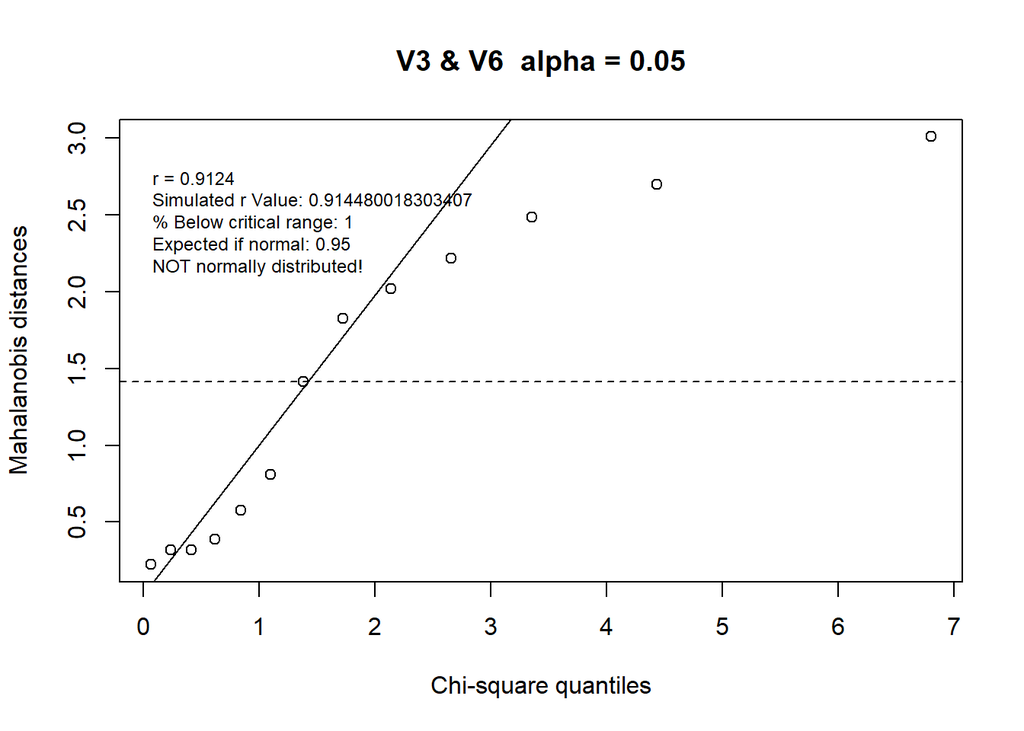

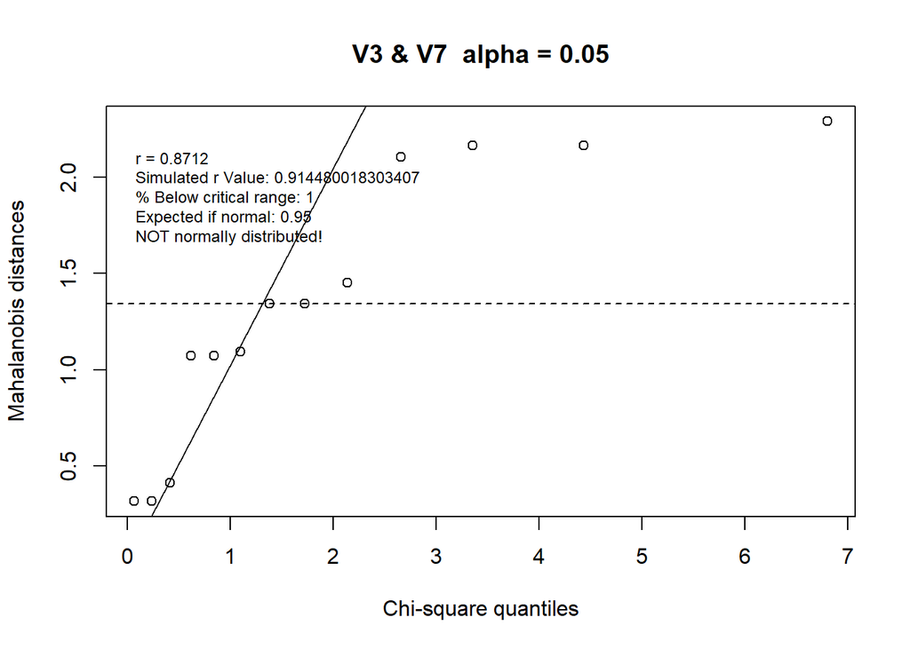

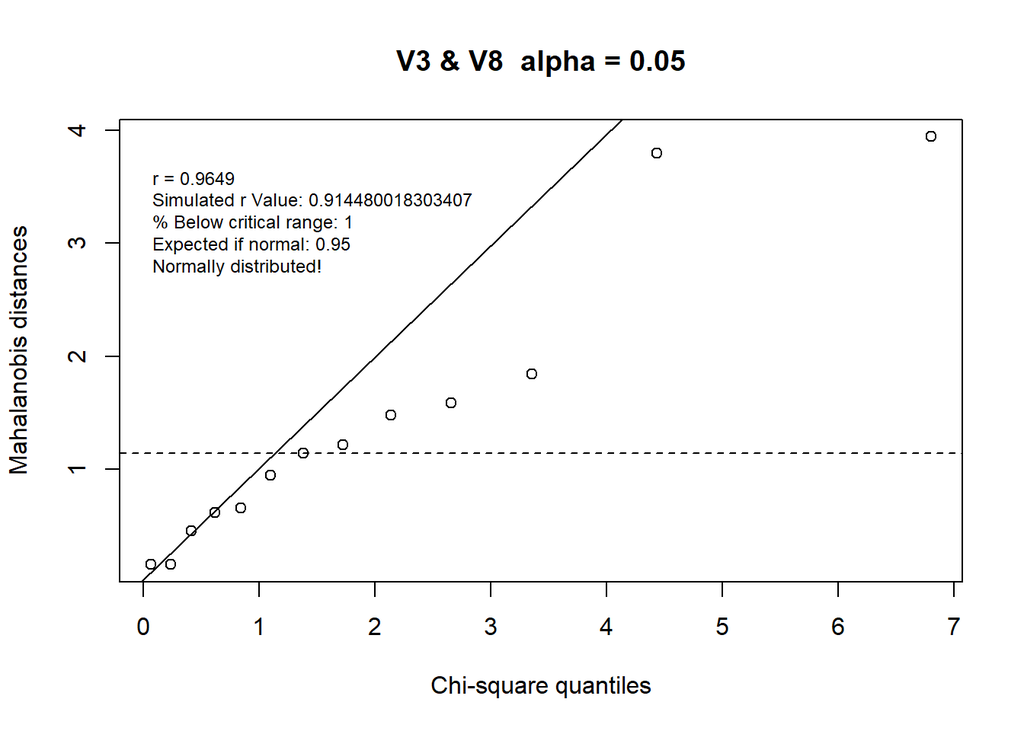

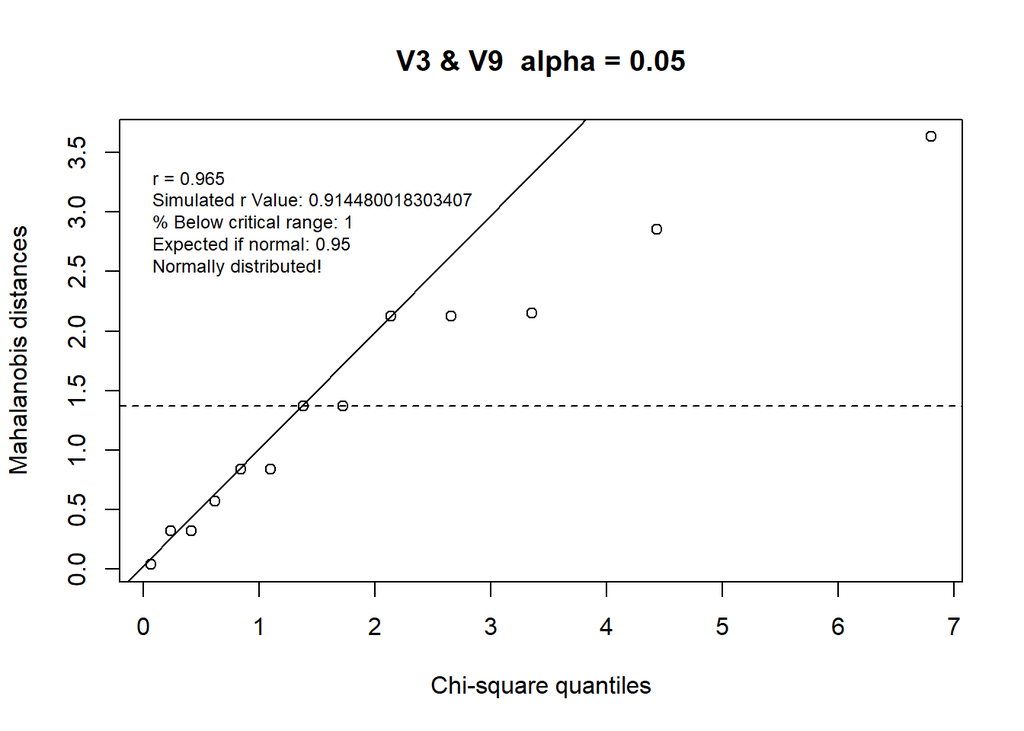

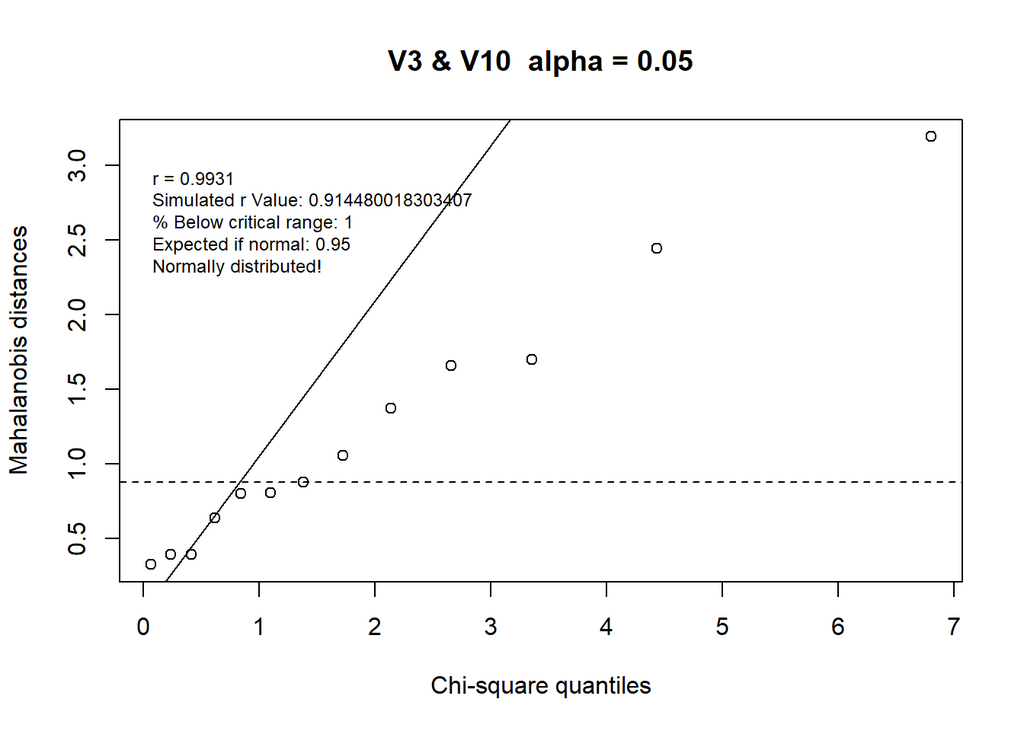

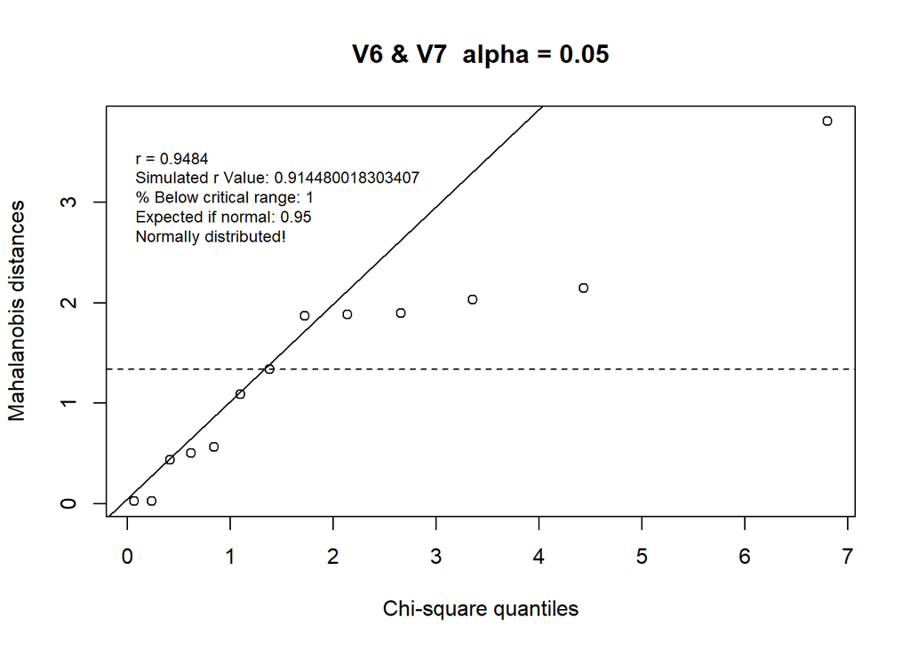

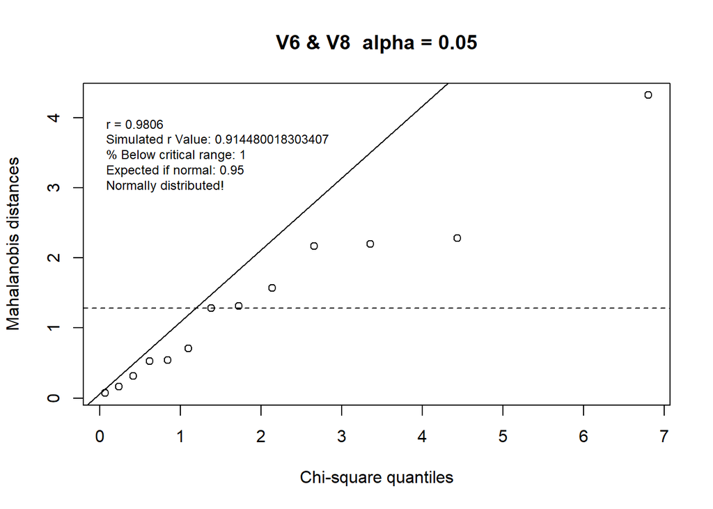

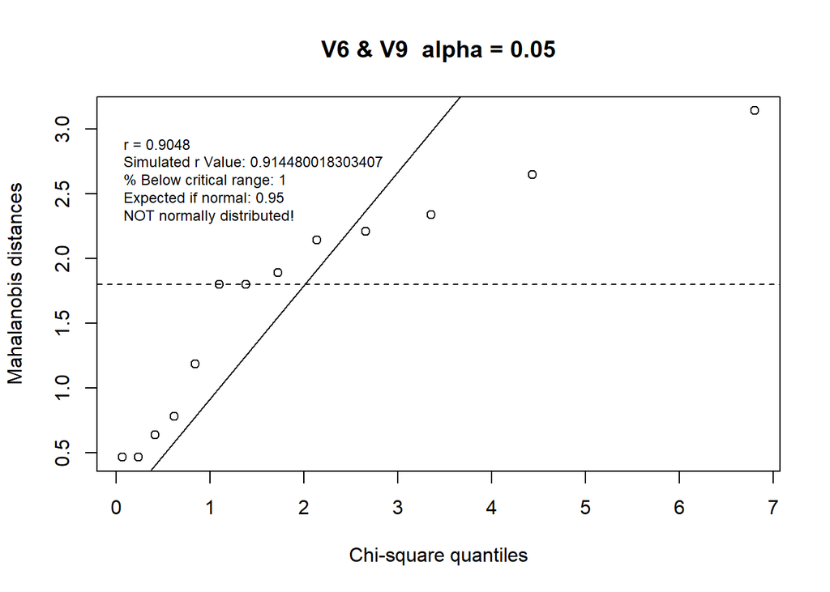

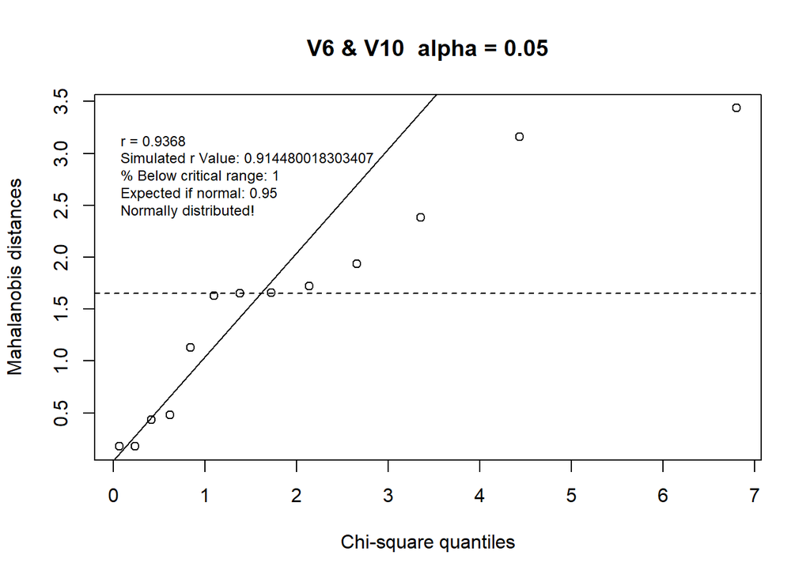

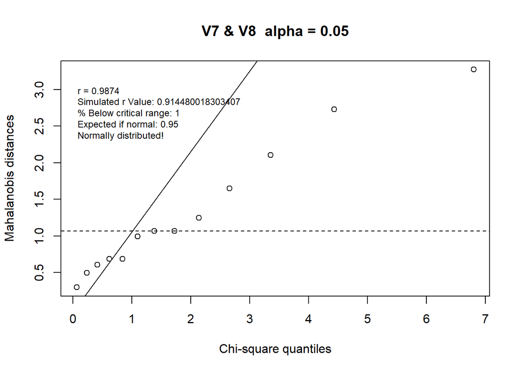

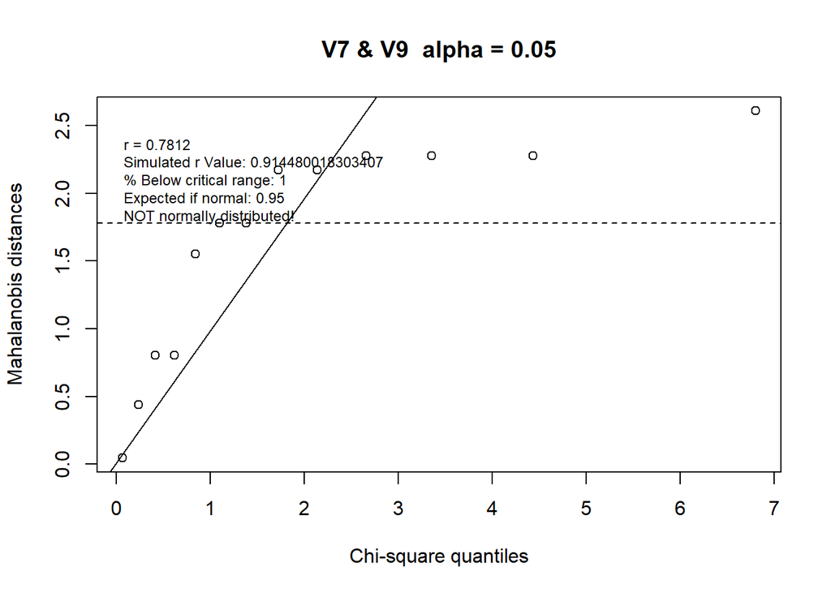

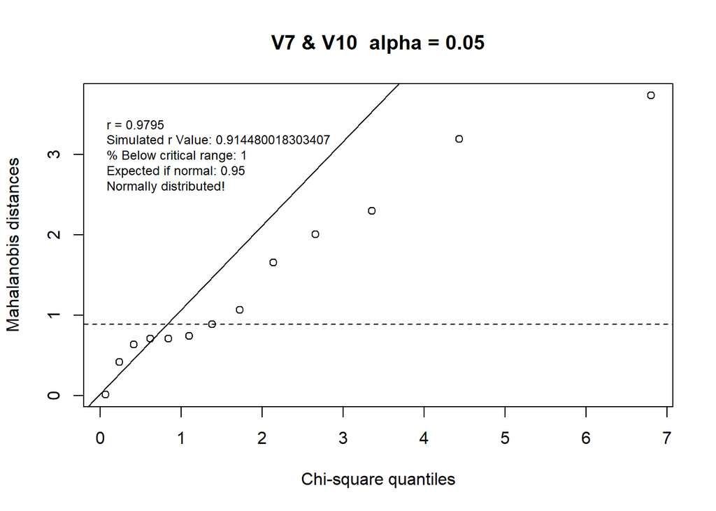

[3 more figures not shown]

```r
bivar_pairs(z_df, remove_outliers = TRUE, n_outliers = 2)
```

```r
z_df <- z_df[, -5]
z_df
```

```
##          V3       V6        V7        V8      V10
## 1  21.97496 18.98157 0.3815453 10.646448 1.411687
## 6  21.97496 22.17264 0.3815453 11.831190 1.425310
## 9  20.76886 20.87777 0.6251913 16.032002 1.425310
## 10 24.24630 18.47035 0.3815453 14.222076 1.438345
## 13 25.32210 19.47668 1.1319389 16.032002 1.460042
## 14 20.76886 19.95701 0.9344521 17.245838 1.434662
## 16 20.76886 19.95701 0.9344521 18.465053 1.434662
## 18 16.77290 22.58421 1.6042980  6.568119 1.467938
## 22 21.97496 16.82356 1.1319389 10.057017 1.449105
## 27 23.13217 21.75148 1.2736949 14.823879 1.454614
## 29 27.37378 17.39327 0.9344521 18.465053 1.449105
## 31 25.32210 20.87777 0.9344521 23.390255 1.441548
## 32 19.50654 18.47035 0.9344521 19.689353 1.425310
## 34 23.13217 20.42370 1.2736949 14.823879 1.461160
## 40 20.76886 17.39327 0.6251913 12.426341 1.427954
```

## All attributes

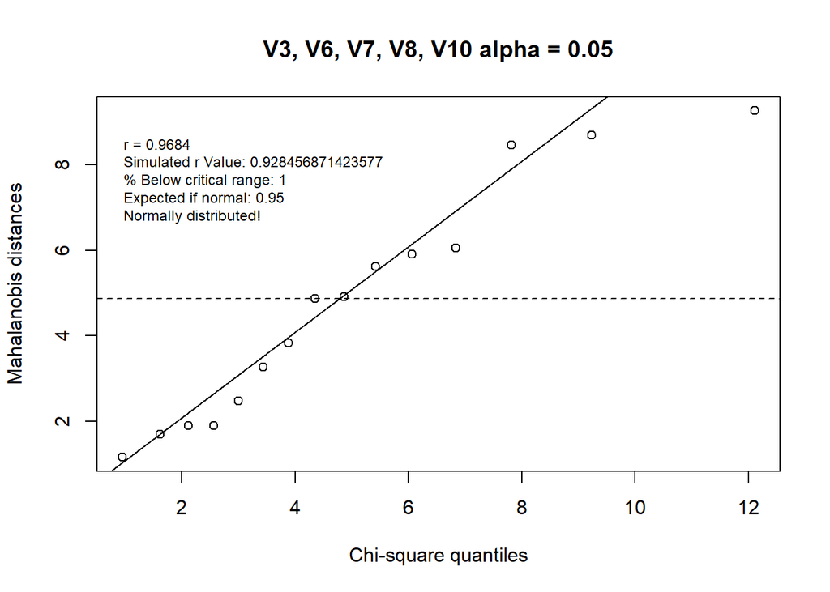

```r
sim_cor <- FindcrikChi(n = length(z_df[,1]),
                          p = length(colnames(z_df)),
                          alpha = 0.05,
                          10000)

multi_var_norm(z_df, sim_cor, 0.05, "V3, V6, V7, V8, V10")
```

Okay, so we need to drop V9, and then we have a multivariate distribution, however, remember, that we removed some rows where V0 was 0, so let us now, start from the complete beginning and do the same test:

```r
z_df <- df[, -5]

i = 1
for (colname in colnames(z_df)){
  z_df <- subset(z_df, z_df[,i] > 1)
  i = i + 1
}
z_df
```

```
##     V3  V6  V7   V8 V10
## 1  110 180 1.5 10.5  70
## 2  110 290 2.0 17.0 105
## 6  110 250 1.5 11.5  90
## 9  100 220 2.0 15.0  90
## 10 130 170 1.5 13.5 120
## 13 140 190 4.0 15.0 230
## 14 100 200 3.0 16.0 110
## 16 100 200 3.0 17.0 110
## 18  70 260 9.0  7.0 320
## 22 110 140 4.0 10.0 160
## 27 120 240 5.0 14.0 190
## 29 160 150 3.0 17.0 160
## 31 140 220 3.0 21.0 130
## 32  90 170 3.0 18.0  90
## 34 120 210 5.0 14.0 240
## 40 100 150 2.0 12.0  95
```

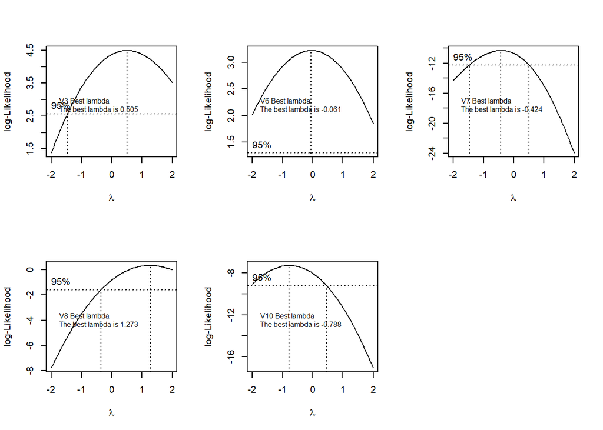

```r
par(mfrow= c(2, 3))
i = 1
for (colname in colnames(z_df)){
  z_df[, i] <- box_cox_transformation(z_df[, i], name = colname)
  i = i + 1
}


i = 1
par(mfrow= c(2, 3))
```

```r
for (colname in colnames(z_df)){
  test_norm(z_df[, i], name = paste0(colname, " (Transformed) "))
  i = i + 1
}
```

[figure not shown]

Yep they are still normal.  
Let us test bivariate normality:

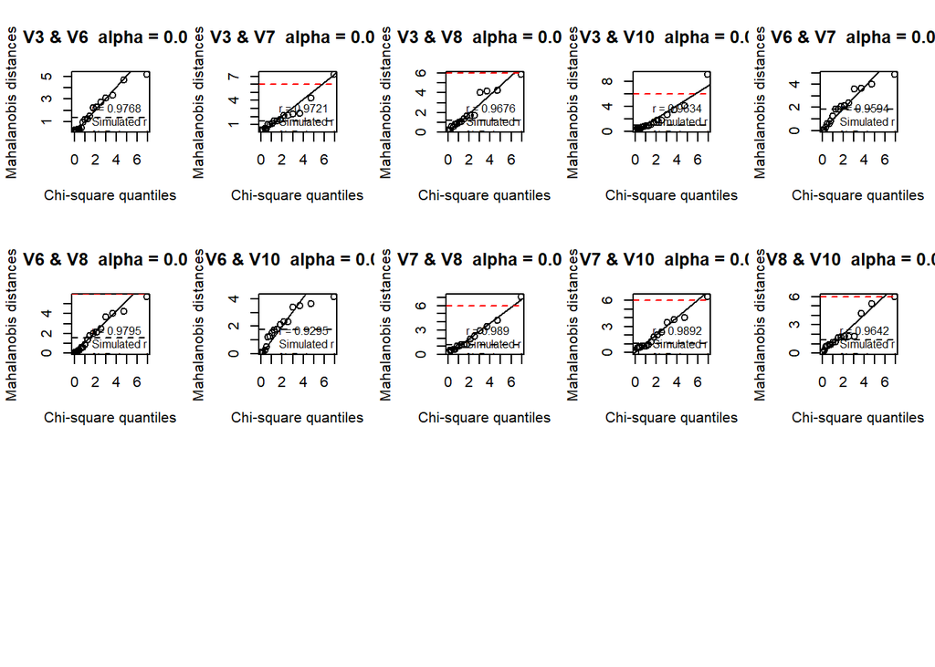

```r
par(mfrow = c(3, 5))
bivar_pairs(z_df)
```

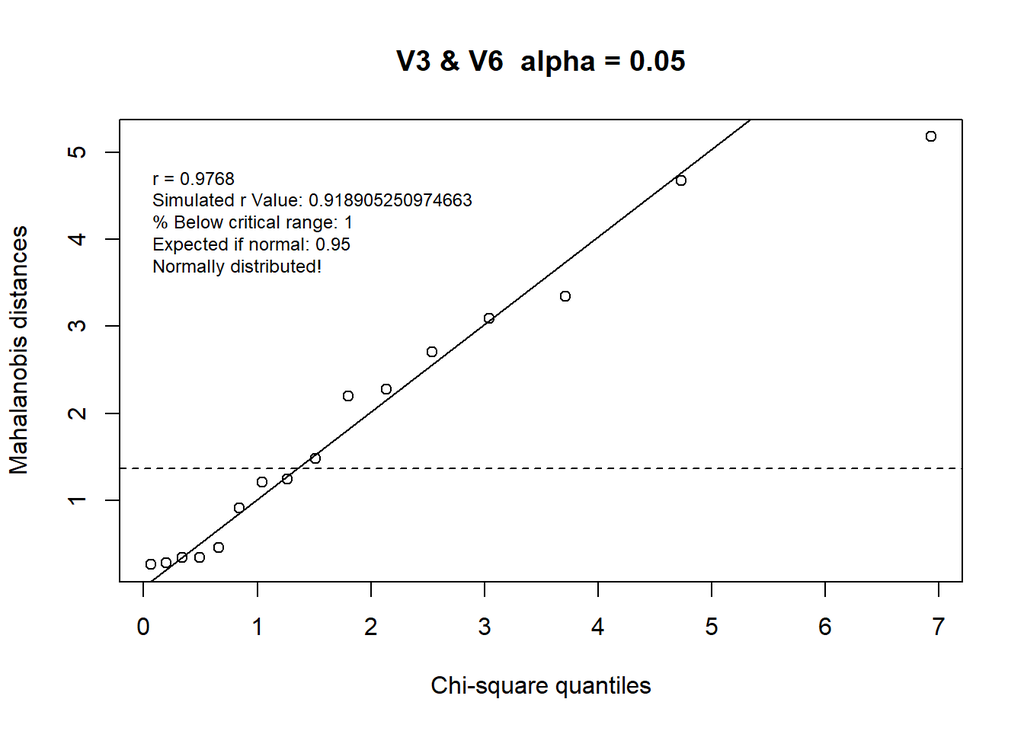

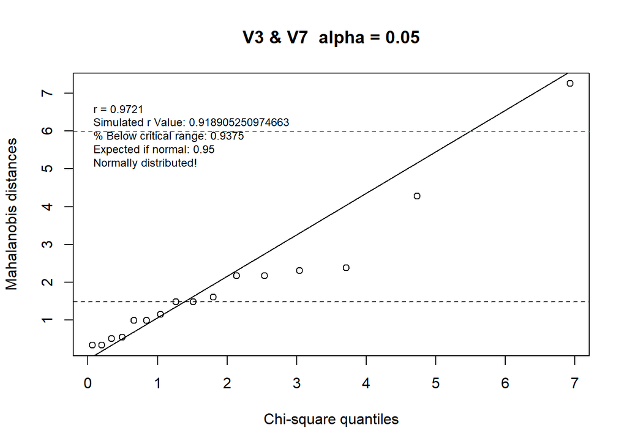

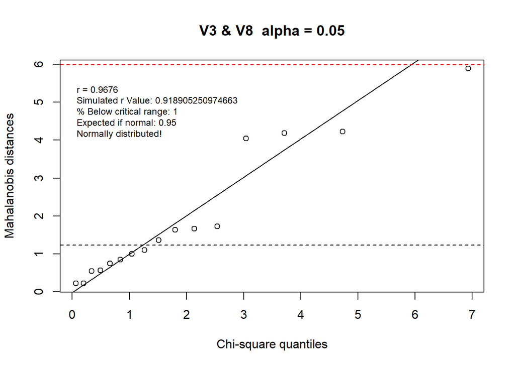

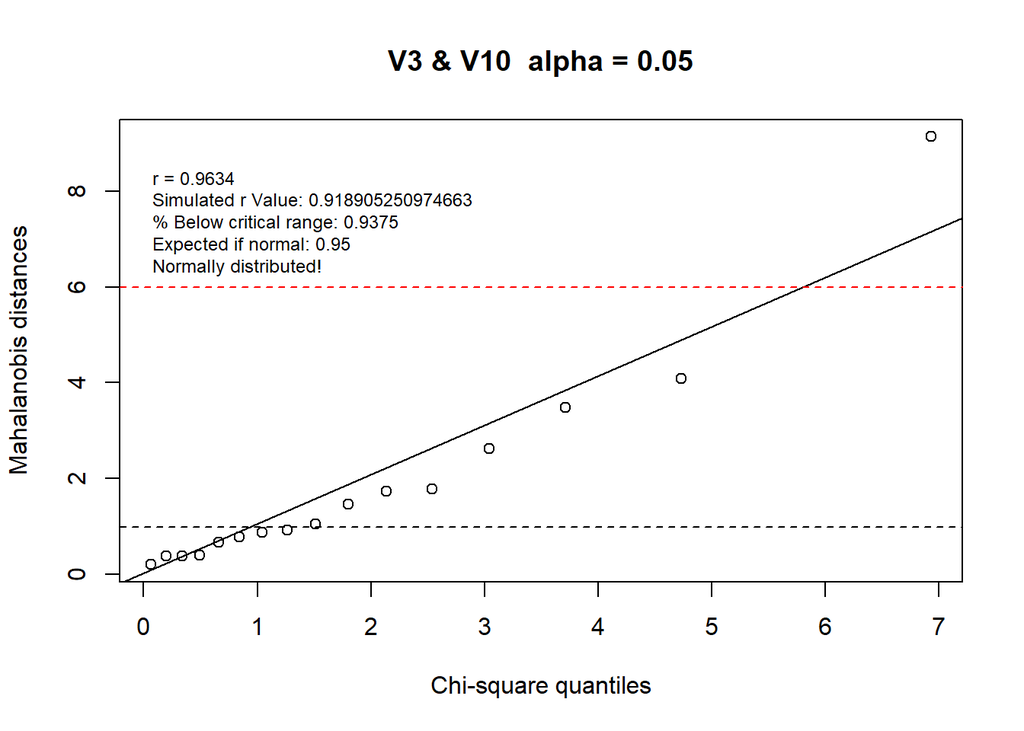

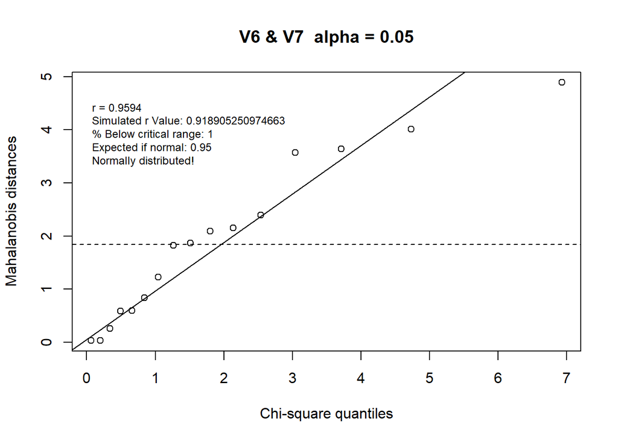

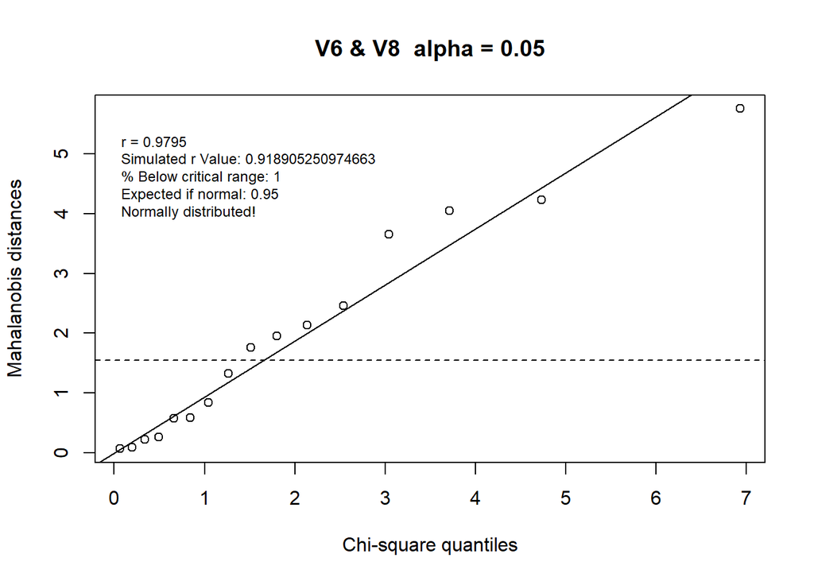

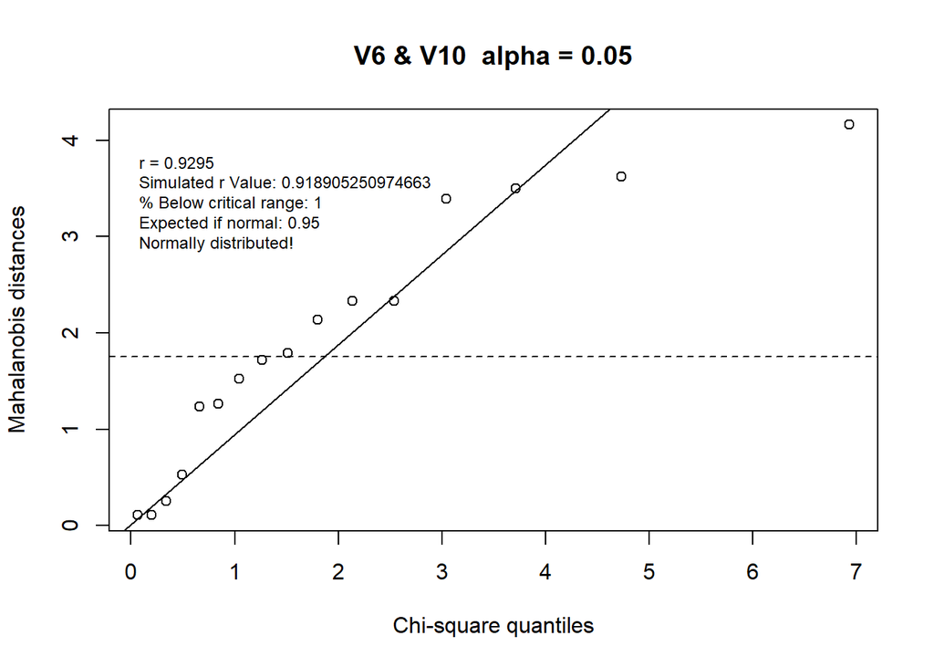

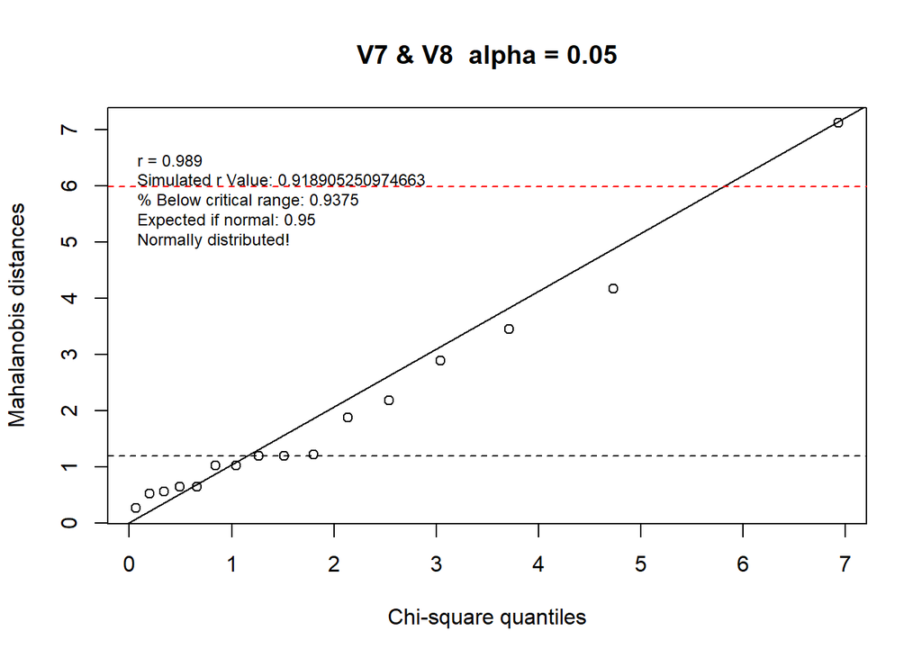

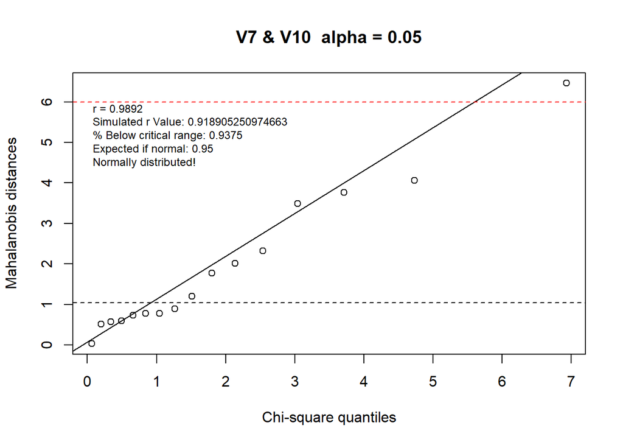

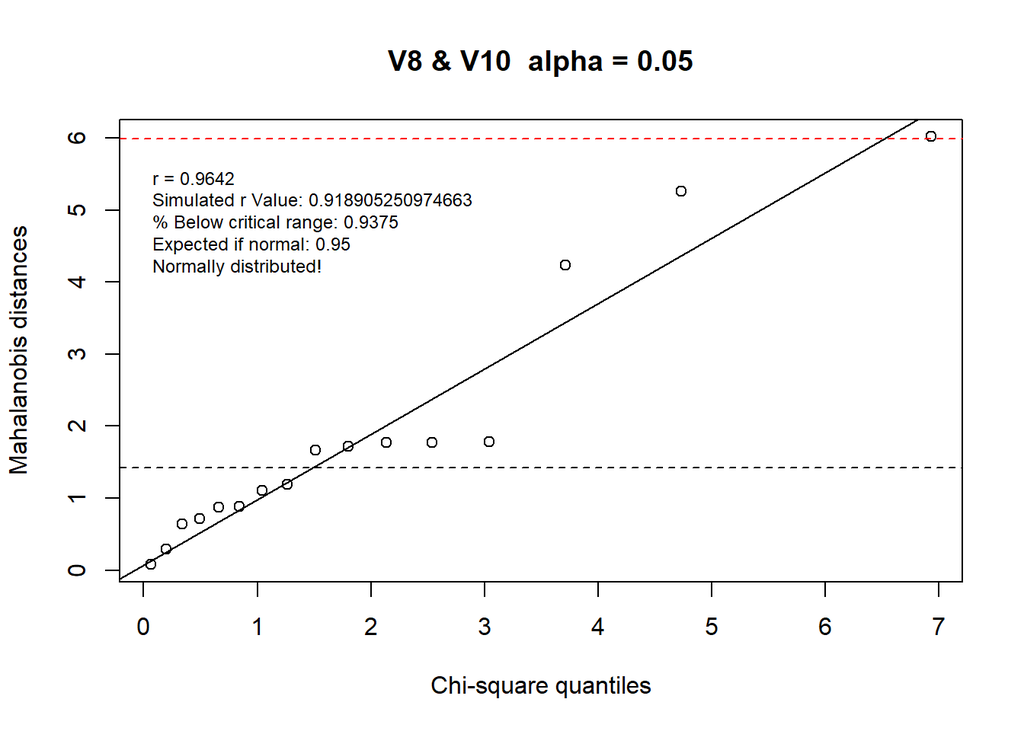

```r
bivar_pairs(z_df)
```

All the pairs are normal. Let us check for all attributes:

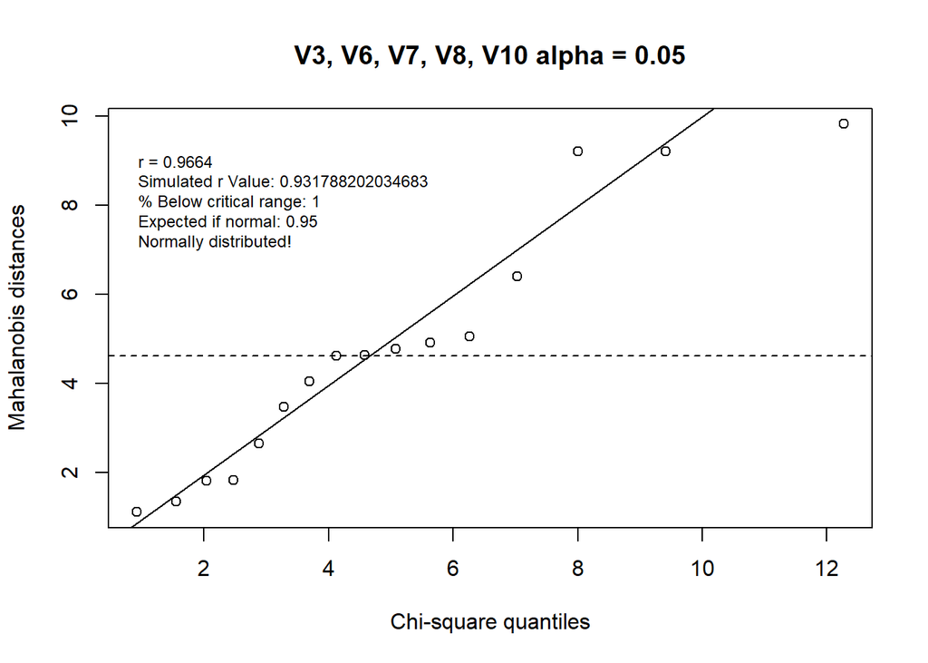

```r
sim_cor <- FindcrikChi(n = length(z_df[,1]),
                          p = length(colnames(z_df)),
                          alpha = 0.05,
                          10000)

multi_var_norm(z_df, sim_cor, 0.05, "V3, V6, V7, V8, V10")
```

They are likewise normally distributed.

## Conclusion

This gives us three options  
- option 1: Use the dataframe with V3, V6, V7, V8, V9, V10, without any transformations. This is not normally distributed, but retains most of its attributes.  
- Option 2: Use the data frame V3, V8, V10 transformed, since these are normally distributeed  
- Option 3: Use the data frame V3, V6, V7, V8, V10 as transformed and where the 0s are removed from from V6, V7 since these are normally distributed.

```r
# option 1
opt_1 <- df
opt_1
```

```
##     V3  V6  V7   V8 V9 V10
## 1  110 180 1.5 10.5 10  70
## 2  110 290 2.0 17.0  1 105
## 3  110 180 0.0 12.0 13  55
## 4  110 180 0.0 12.0 13  65
## 5  110 280 0.0 15.0  9  45
## 6  110 250 1.5 11.5 10  90
## 7  110 260 0.0 21.0  3  40
## 8  110 180 0.0 12.0 12  55
## 9  100 220 2.0 15.0  6  90
## 10 130 170 1.5 13.5 10 120
## 12 110 200 0.0 21.0  3  35
## 13 140 190 4.0 15.0 14 230
## 14 100 200 3.0 16.0  3 110
## 15 110 140 0.0 13.0 12  25
```

[output cut: 28 more lines]

```r
#option 2
par(mfrow = c(1, 3))
opt_2 <- df[, c(1, 4, 6)]
i = 1
for (colname in colnames(opt_2)){
  opt_2[, i] <- box_cox_transformation(opt_2[, i], name = colname)
  i = i + 1
}
```

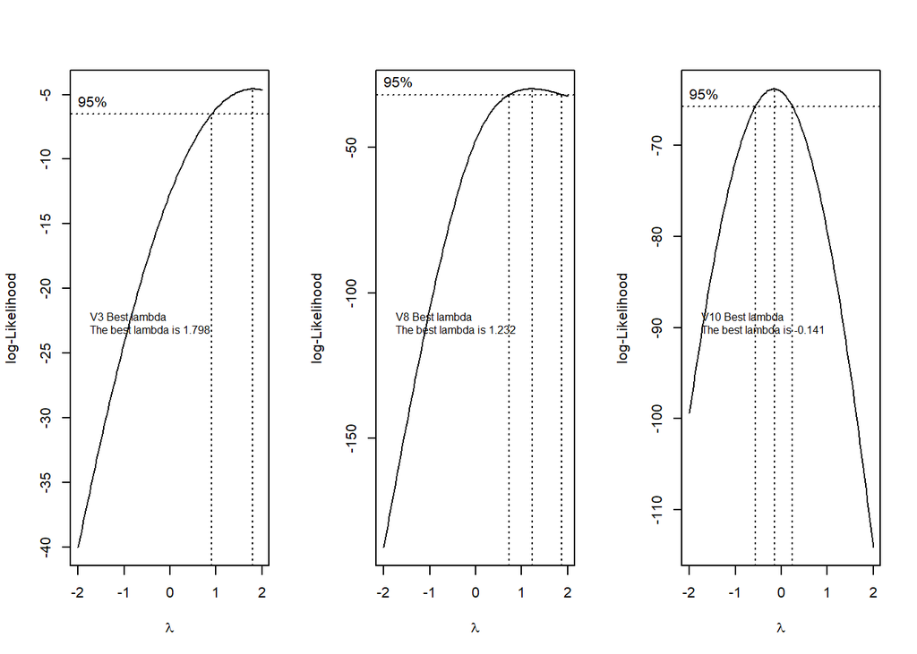

```r
opt_2
```

```
##           V3        V8      V10
## 1  2603.1861 13.901844 3.193639
## 2  2603.1861 25.831711 3.409732
## 3  2603.1861 16.533572 3.059111
## 4  2603.1861 16.533572 3.152787
## 5  2603.1861 22.023468 2.943620
## 6  2603.1861 15.647317 3.329034
## 7  2603.1861 33.756737 2.874291
## 8  2603.1861 16.533572 3.059111
## 9  2193.1315 22.023468 3.329034
## 10 3515.3934 19.243029 3.478227
## 12 2603.1861 33.756737 2.794282
## 13 4016.5198 22.023468 3.794059
## 14 2193.1315 23.913758 3.433741
## 15 2603.1861 18.331685 2.585848
```

[output cut: 28 more lines]

```r
#option 3
opt_3 <- z_df
opt_3
```

```
##          V3       V6        V7        V8      V10
## 1  19.28530 4.455168 0.3725084 14.880358 1.224580
## 2  19.28530 4.798334 0.6005294 28.140430 1.236790
## 6  19.28530 4.692601 0.3725084 16.803390 1.232601
## 9  18.28591 4.600768 0.6005294 23.880816 1.232601
## 10 21.15734 4.413370 0.3725084 20.785335 1.240030
## 13 22.03974 4.494572 1.0480619 23.880816 1.251741
## 14 18.28591 4.531835 0.8781338 25.992462 1.237958
## 16 18.28591 4.531835 0.8781338 28.140430 1.237958
## 18 14.94516 4.720634 1.4291262  8.564982 1.255748
## 22 19.28530 4.270306 1.0480619 13.937137 1.245952
## 27 20.24065 4.663352 1.1663035 21.807242 1.248900
## 29 23.71550 4.321337 0.8781338 28.140430 1.245952
## 31 22.03974 4.600768 0.8781338 37.066318 1.241814
## 32 17.23571 4.413370 0.8781338 30.323153 1.232601
## 34 20.24065 4.567172 1.1663035 21.807242 1.252318
## 40 18.28591 4.321337 0.6005294 17.782411 1.234129
```

However, I have decided to only use option 2 for normal classifiers, since I believe that to many observatsion have been removed from option 3 (there are only 16 observations left out of the 42 observations).

# Step 4: Find Optimal classifier

I will follow the following process:

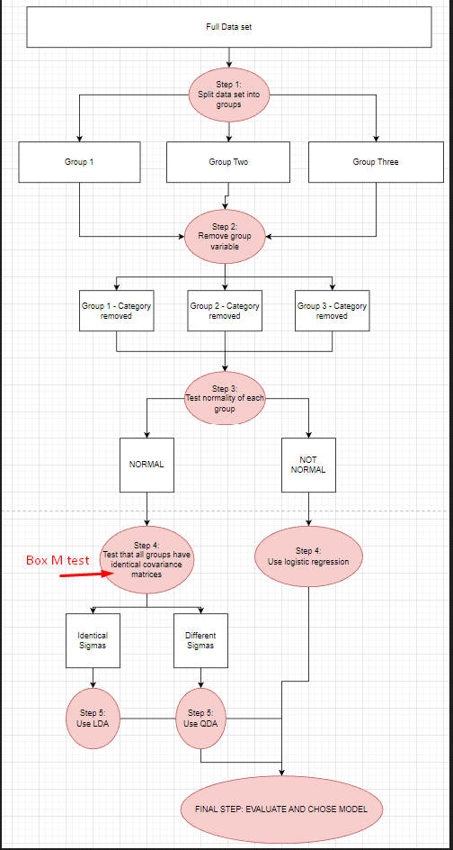

## Optimal Classifier

I Will first split and prepare my data:

```r
z_opt_2 <- full_df
z_opt_2_cat <- full_df[, 11]

par(mfrow = c(1, 3))


opt_2_group_1 <- subset(z_opt_2, full_df[,11] == 1)
opt_2_group_2 <- subset(z_opt_2, full_df[,11] == 2)
opt_2_group_3 <- subset(z_opt_2, full_df[,11] == 3)

opt_2_group_1 <-na.omit(opt_2_group_1[, c(3, 8, 10, 11)])
opt_2_group_2 <-na.omit(opt_2_group_2[, c(3, 8, 10, 11)])
opt_2_group_3 <-na.omit(opt_2_group_3[, c(3, 8, 10, 11)])

opt_2_group_1
```

```
##     V3   V8 V10 V11
## 1  110 10.5  70   1
## 2  110 17.0 105   1
## 3  110 12.0  55   1
## 4  110 12.0  65   1
## 5  110 15.0  45   1
## 6  110 11.5  90   1
## 7  110 21.0  40   1
## 8  110 12.0  55   1
## 9  100 15.0  90   1
## 10 130 13.5 120   1
## 12 110 21.0  35   1
## 13 140 15.0 230   1
## 14 100 16.0 110   1
## 15 110 13.0  25   1
## 16 100 17.0 110   1
## 17 110 16.0  60   1
```

```r
opt_2_group_2
```

```
##     V3 V8 V10 V11
## 18  70  7 320   2
## 19 110 11  30   2
## 20 100 21  35   2
## 21 110 13  20   2
## 22 110 10 160   2
## 23 110 21  30   2
## 24 110 11  30   2
## 25 110 14  25   2
## 26 100 14 100   2
## 27 120 14 190   2
## 28 110 17  60   2
## 29 160 17 160   2
## 30 120 15  40   2
## 31 140 21 130   2
## 32  90 18  90   2
## 33 100 20  45   2
## 34 120 14 240   2
## 35 110 22  35   2
## 36 110  9  40   2
## 37 110 16  55   2
```

```r
opt_2_group_3
```

```
##     V3 V8 V10 V11
## 38 120 12  35   3
## 39 120 12  45   3
## 40 100 12  95   3
## 41  50 13  15   3
## 42  50 10  50   3
## 43 100  1 110   3
```

```r
opt_2_group_1
```

```
##     V3   V8 V10 V11
## 1  110 10.5  70   1
## 2  110 17.0 105   1
## 3  110 12.0  55   1
## 4  110 12.0  65   1
## 5  110 15.0  45   1
## 6  110 11.5  90   1
## 7  110 21.0  40   1
## 8  110 12.0  55   1
## 9  100 15.0  90   1
## 10 130 13.5 120   1
## 12 110 21.0  35   1
## 13 140 15.0 230   1
## 14 100 16.0 110   1
## 15 110 13.0  25   1
## 16 100 17.0 110   1
## 17 110 16.0  60   1
```

```r
opt_2_group_2
```

```
##     V3 V8 V10 V11
## 18  70  7 320   2
## 19 110 11  30   2
## 20 100 21  35   2
## 21 110 13  20   2
## 22 110 10 160   2
## 23 110 21  30   2
## 24 110 11  30   2
## 25 110 14  25   2
## 26 100 14 100   2
## 27 120 14 190   2
## 28 110 17  60   2
## 29 160 17 160   2
## 30 120 15  40   2
## 31 140 21 130   2
## 32  90 18  90   2
## 33 100 20  45   2
## 34 120 14 240   2
## 35 110 22  35   2
## 36 110  9  40   2
## 37 110 16  55   2
```

```r
opt_2_group_3
```

```
##     V3 V8 V10 V11
## 38 120 12  35   3
## 39 120 12  45   3
## 40 100 12  95   3
## 41  50 13  15   3
## 42  50 10  50   3
## 43 100  1 110   3
```

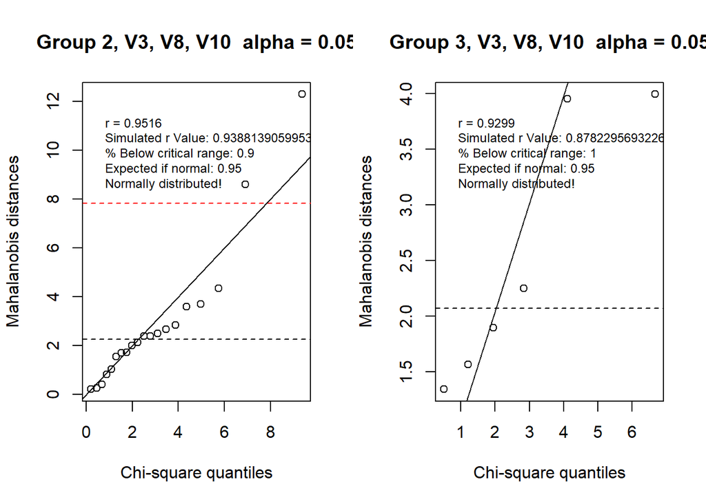

```r
par(mfrow = c(1, 2))
# Group 1
sim_cor <- FindcrikChi(n = length(opt_2_group_1[,1]),
                          p = length(colnames(opt_2_group_1)),
                          alpha = 0.05,
                          10000)
#multi_var_norm(opt_2_group_1[, -4], sim_cor, 0.05, "Group 1, V3, V8, V10 ")

# Group 2
sim_cor <- FindcrikChi(n = length(opt_2_group_2[,1]),
                          p = length(colnames(opt_2_group_2)),
                          alpha = 0.05,
                          10000)
multi_var_norm(opt_2_group_2[, -4], sim_cor, 0.05, "Group 2, V3, V8, V10 ")

# Group 1
sim_cor <- FindcrikChi(n = length(opt_2_group_3[,1]),
                          p = length(colnames(opt_2_group_3)),
                          alpha = 0.05,
                          10000)
multi_var_norm(opt_2_group_3[, -4], sim_cor, 0.05, "Group 3, V3, V8, V10 ")
```

Since we can’t check group one we should assume that it is not normally distributed, however in this case let us assume it is normal just for demonstration.

Now we know that the two groups are normal, so now we need to test their covariance matrices using the Box-m test for homogeneity  
- h0: hypothesis: The covariance matrices are equal  
- h1: The covariance matrices differ.

We calculate the C value and test if it is above a critical chi-square value using the function below

```r
box_m_test <- function(df, group_index, significance = 0.95){
  #This takes the full dataframe and the index of the column which contains the groups

  n <- nrow(df)
  p <- ncol(df[, -group_index])
  groups <- unique(df[, group_index])
  g <- length(groups)

  # get w
  w <- 0
  for (group in groups){
    mask <- df[,group_index] == group
    group_df <- df[mask, ]
    n_g <- nrow(group_df)
    s_g <- cov(group_df[, -group_index])
    w <- w + (n_g - 1) * s_g
  }
  # get w
  spooled <- w/(n - g)

  # get M
  M_sum <- 0
  for (group in groups){
    mask <- df[,group_index] == group
    group_df <- df[mask, ]
    n_g <- nrow(group_df)
    s_g <- cov(group_df[, -group_index])
    M_sum <- ((n_g - 1) * log(det(s_g))) + M_sum
  }
  M <- (n-g)*log(det(spooled)) - M_sum

  # get u
  sum_u <- 0
  for (group in groups){
    mask <- df[,group_index] == group
    group_df <- df[mask, ]
    n_g <- nrow(group_df)
    s_g <- cov(group_df[, -group_index])
    sum_u <- sum_u + (1/(n_g - 1))
  }
  u <-  ( sum_u - 1/(n-g)) * ( (2*p^2 + 3*p - 1) / (6*(p+1)*(g-1)))

  # Test statistic
  C <- (1-u)*M

  # Critcal value v
  critvalue <- qchisq(significance,p*(p+1)*(g-1)/2)   #v=p*(p+1)*(g-1)/2#

  ### final decision ####
  decisionflag <- (C > critvalue)

  writeLines(paste0("u :                          ", u, "\n",
                    "M statistic:                 ", M, "\n",
                    "C value (Chi-squared value): ", C, "\n",
                    "Critival value (v):          ", critvalue, "\n",
                    "Equal covariance matrices:   ", decisionflag, "\n"))
}
```

Let us test the function, with significance 0.05

```r
box_m_test(df = rbind(opt_2_group_1, opt_2_group_2, opt_2_group_3),
           group_index = 4)
```

```
## u :                          0.15906432748538
## M statistic:                 31.4002334672491
## C value (Chi-squared value): 26.4055764478972
## Critival value (v):          21.0260698174831
## Equal covariance matrices:   TRUE
```

With 0.01 significance:

```r
box_m_test(df = rbind(opt_2_group_1, opt_2_group_2, opt_2_group_3),
           group_index = 4,
           significance = 0.99)
```

```
## u :                          0.15906432748538
## M statistic:                 31.4002334672491
## C value (Chi-squared value): 26.4055764478972
## Critival value (v):          26.2169673055358
## Equal covariance matrices:   TRUE
```

```r
library(heplots)
temp <- rbind(opt_2_group_1, opt_2_group_2, opt_2_group_3)
boxM(temp[, -4], temp$V11)
```

```
##
##  Box's M-test for Homogeneity of Covariance Matrices
##
## data:  temp[, -4]
## Chi-Sq (approx.) = 26.406, df = 12, p-value = 0.009401
```

```r
z_opt_2 <- full_df
z_opt_2[, 3] <- box_cox_transformation(z_opt_2[, 3], name = "V3")
```

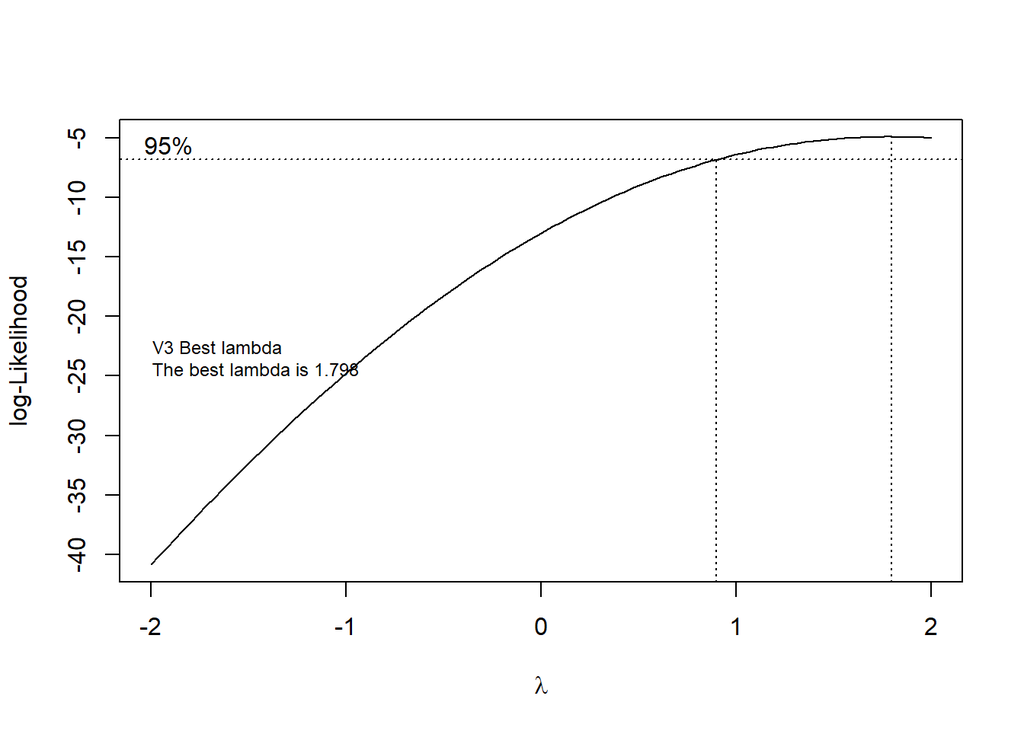

```r
z_opt_2[, 8] <- box_cox_transformation(z_opt_2[, 8], name = "V8")
```

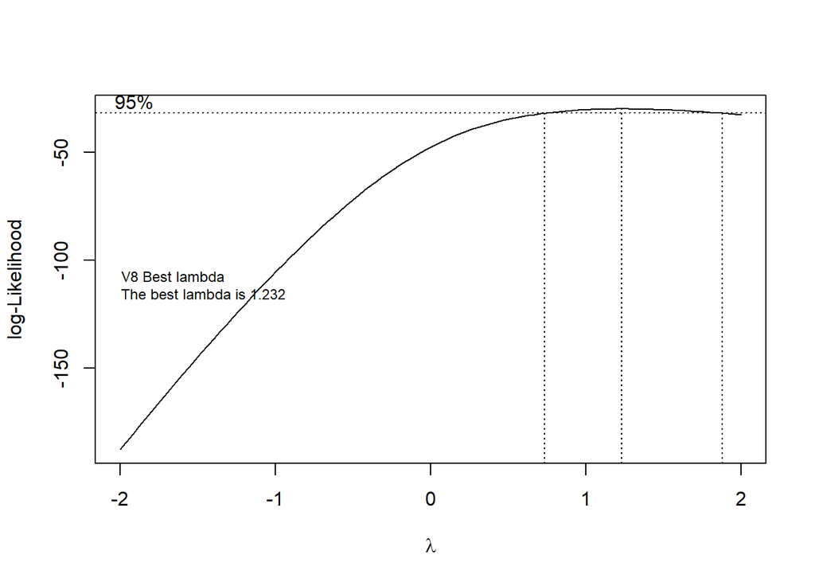

```r
z_opt_2[, 10] <- box_cox_transformation(z_opt_2[, 10], name = "V10")
```

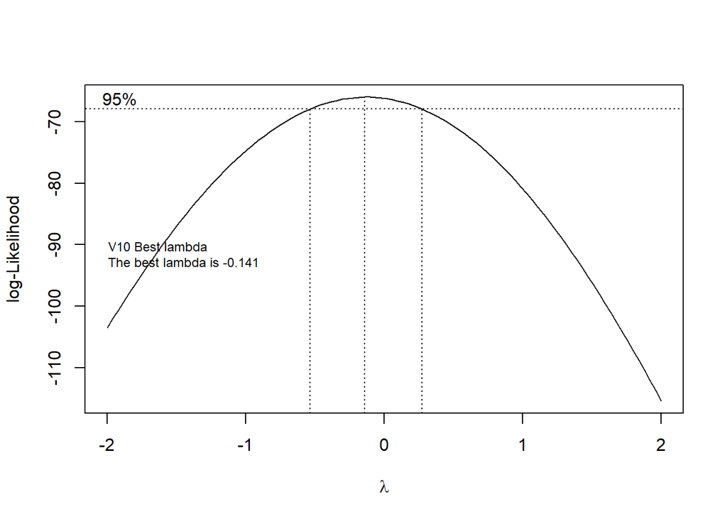

```r
z_opt_2 <- z_opt_2[-11,]
z_opt_2 <- z_opt_2[, c(3, 8, 10, 11)]
```

## Creating classifers and evaluating

## 70 - 30 split and APER

We split into training and test data

```r
z_opt_2_train <- z_opt_2[sample(1:nrow(z_opt_2), 30),] # 70%
z_opt_2_test <- z_opt_2[sample(1:nrow(z_opt_2), 12),] # 30%
```

We then have some simple evalutaion techniques such as APER (misclassifications divided by number of samples)

```r
aper <- function(preds, obs){
  n_misclassifications <- 0
  i <- 1
  for (val in preds){

    if (val != obs[i]){
      n_misclassifications = n_misclassifications + 1
    }

    i = i + 1
  }
  return(n_misclassifications / length(preds))

}

acc <- function(preds, obs){
  correct <- 0
  i <- 1
  for (val in preds){

    if (val == obs[i]){
      correct = correct + 1
    }

    i = i + 1
  }
  return(correct / length(preds))
}

confusion_matrix <- function(preds, observed){
  # Alternatively user this code below
  # library(caret)
  # confusionMatrix(as.factor(predictions$class), as.factor(observed))
  return(table(preds, observed))
}
```

### LDA

We start by creating the LDA model:

```r
library(MASS)
lda_model <- lda(V11~., data = z_opt_2_train)
lda_model
```

```
## Call:
## lda(V11 ~ ., data = z_opt_2_train)
##
## Prior probabilities of groups:
##         1         2         3
## 0.3333333 0.4666667 0.2000000
##
## Group means:
##         V3       V8      V10
## 1 2794.735 21.67887 3.262363
## 2 2700.792 22.37316 3.071542
## 3 1955.850 13.49595 2.963946
##
## Coefficients of linear discriminants:
##               LD1           LD2
## V3  -0.0006687581 -0.0004536305
## V8  -0.1205319532 -0.0245463988
## V10 -0.8041670072  2.7739335512
##
## Proportion of trace:
##    LD1    LD2
## 0.9046 0.0954
```

```r
lda_preds <- predict(lda_model, z_opt_2_test)
lda_preds
```

```
## $class
##  [1] 3 1 3 2 2 2 2 1 1 1 3 2
## Levels: 1 2 3
##
## $posterior
##             1          2           3
## 43 0.06003348 0.05638562 0.883580908
## 34 0.62744593 0.34847556 0.024078509
## 36 0.16441812 0.36409515 0.471486735
## 7  0.32589478 0.66552129 0.008583934
## 3  0.30290625 0.49856454 0.198529216
## 19 0.17026292 0.48400921 0.345727876
## 39 0.27762412 0.57821118 0.144164705
## 40 0.39448863 0.39139658 0.214114789
## 13 0.60224976 0.39206002 0.005690216
```

[output cut: 18 more lines]

#### Evaluate LDA

```r
aper(lda_preds$class, z_opt_2_test$V11)
```

```
## [1] 0.5
```

```r
acc(lda_preds$class, z_opt_2_test$V11)
```

```
## [1] 0.5
```

```r
#library(caret)
# confusionMatrix(as.factor(lda_preds$class), as.factor(z_opt_2_test$V11))
confusion_matrix(lda_preds$class, z_opt_2_test$V11)
```

```
##      observed
## preds 1 2 3
##     1 2 1 1
##     2 2 2 1
##     3 0 1 2
```

We can see that class 1 is prone to misclassificaitons. ### QDA

```r
library(MASS)
qda_model <- qda(V11~., data = z_opt_2_train)
qda_model
```

```
## Call:
## qda(V11 ~ ., data = z_opt_2_train)
##
## Prior probabilities of groups:
##         1         2         3
## 0.3333333 0.4666667 0.2000000
##
## Group means:
##         V3       V8      V10
## 1 2794.735 21.67887 3.262363
## 2 2700.792 22.37316 3.071542
## 3 1955.850 13.49595 2.963946
```

```r
qda_preds <- predict(qda_model, z_opt_2_test)
qda_preds
```

```
## $class
##  [1] 3 1 2 2 1 2 2 1 1 2 3 2
## Levels: 1 2 3
##
## $posterior
##              1         2           3
## 43 0.007797458 0.0816206 0.910581945
## 34 0.509557855 0.4881568 0.002285376
## 36 0.109900596 0.4879259 0.402173523
## 7  0.332246251 0.6665895 0.001164262
## 3  0.494237755 0.3619359 0.143826373
## 19 0.052548849 0.5992991 0.348152101
## 39 0.167031117 0.6010966 0.231872282
## 40 0.449009995 0.4320487 0.118941261
## 13 0.578483379 0.4199623 0.001554357
## 16 0.333249146 0.6653488 0.001402068
## 41 0.001488332 0.1088926 0.889619026
## 23 0.155965712 0.8387635 0.005270748
```

#### Evaluate QDA

```r
aper(qda_preds$class, z_opt_2_test$V11)
```

```
## [1] 0.4166667
```

```r
acc(qda_preds$class, z_opt_2_test$V11)
```

```
## [1] 0.5833333
```

```r
#library(caret)
# confusionMatrix(as.factor(lda_preds$class), as.factor(z_opt_2_test$V11))
confusion_matrix(qda_preds$class, z_opt_2_test$V11)
```

```
##      observed
## preds 1 2 3
##     1 2 1 1
##     2 2 3 1
##     3 0 0 2
```

### Logistic Regression

```r
library(nnet)
logistic_train <- z_opt_2_train
logistic_train$V11 <- as.factor(logistic_train$V11)
logistic <- multinom(V11~., data=logistic_train)
logistic
```

```
## Call:
## multinom(formula = V11 ~ ., data = logistic_train)
##
## Coefficients:
##   (Intercept)            V3           V8       V10
## 2    5.228621  0.0001512352  0.002644872 -1.694624
## 3   13.925494 -0.0012877172 -0.226989242 -2.360012
##
## Residual Deviance: 48.71273
## AIC: 64.71273
```

```r
logistic_preds <- predict(logistic, z_opt_2_test, type = "class")
logistic_preds
```

```
##  [1] 3 1 3 2 2 2 2 1 1 1 3 2
## Levels: 1 2 3
```

#### Evaluate Logistic

```r
aper(logistic_preds, z_opt_2_test$V11)
```

```
## [1] 0.5
```

```r
acc(logistic_preds, z_opt_2_test$V11)
```

```
## [1] 0.5
```

```r
#library(caret)
# confusionMatrix(as.factor(lda_preds$class), as.factor(z_opt_2_test$V11))
confusion_matrix(logistic_preds, z_opt_2_test$V11)
```

```
##      observed
## preds 1 2 3
##     1 2 1 1
##     2 2 2 1
##     3 0 1 2
```

## E(AER)

This is also known as cross-validation or hold-one-out. Let us define a function for it:

```r
EAER <- function(data_frame, model_type = "lda") {

  n_misclass <- 0
  for (i in 1:nrow(data_frame)) {
    temp_data <- data_frame[-i,]
    if (model_type == "lda"){
      model <- lda(V11~., data = temp_data)
    }
    else if (model_type == "qda"){
      model <- qda(V11~., data = temp_data)
    }
    else {
      temp_data$V11 <- as.factor(temp_data$V11)
      model <- multinom(V11~., data=temp_data, trace = FALSE)
    }
    pred <- predict(model, data_frame[i,], type = "class")

    if (model_type != "lda" & model_type != "qda"){
      true_prediction = (pred != data_frame[i,4])

    }
    else{
      true_prediction = (pred$class != data_frame[i,4])
    }

    if (true_prediction){
      n_misclass <- n_misclass + 1
    }
  }
  return(n_misclass / length(data_frame[,1]))

}

# Below is how to do it with the built in function
```

Let us evaluate each model:  
#### LDA

```r
lda_eaer <- EAER(z_opt_2, "lda")
lda_acc <- 1 - lda_eaer
print(paste0("EAER: ", lda_eaer," Acc: ", lda_acc))
```

```
## [1] "EAER: 0.666666666666667 Acc: 0.333333333333333"
```

```r
model <- lda(V11~., data = z_opt_2, CV = TRUE)
aper(model$class, z_opt_2$V11)
```

```
## [1] 0.6428571
```

It misclassifies around 66% and has an accuracy of 33%, so all in all pretty terrible.

#### QDA

```r
qda_eaer <- EAER(z_opt_2, "qda")
qda_acc <- 1 - qda_eaer
print(paste0("EAER: ", qda_eaer," Acc: ", qda_acc))
```

```
## [1] "EAER: 0.619047619047619 Acc: 0.380952380952381"
```

```r
model <- qda(V11~., data = z_opt_2, CV = TRUE)
aper(model$class, z_opt_2$V11)
```

```
## [1] 0.6190476
```

The QDA has a slightly lower misclassification rate, but still very close to just guessing.

#### Logistic

```r
logi_eaer <- EAER(z_opt_2, "logistic")
logi_acc <- 1 - logi_eaer
print(paste0("EAER: ", logi_eaer," Acc: ", logi_acc))
```

```
## [1] "EAER: 0.714285714285714 Acc: 0.285714285714286"
```

As before we can see that this model is terrible.

## ROC

ROC (Receiver Operating Characteristic Curve). But it only works with two classes so we will remove class three since it anyways have so few observations. it works by looking at the true positives and false positives:

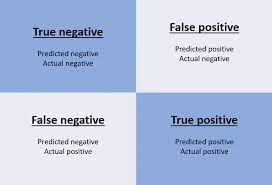

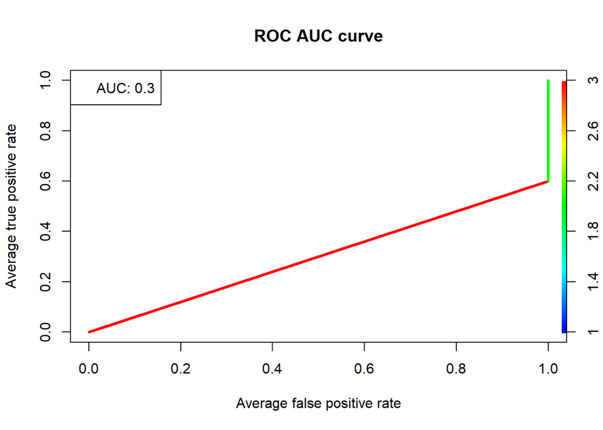

```r
roc_data <- df2<-z_opt_2[!(z_opt_2$V11==3), ]
library(ROCR)
model <- lda(V11~., data = roc_data, CV = TRUE)
predictions <- as.numeric(model$class)
labels <- roc_data$V11
pred <- prediction(predictions, labels)
perf <- performance(pred, "tpr", "fpr")
auc <- performance(pred, measure = "auc")

plot(perf,
     avg= "threshold",
     colorize=TRUE,
     lwd= 3,
     main= "ROC AUC curve")
legend("topleft",
       paste0("AUC: ", auc@y.values[[1]]))
```

```r
#per.auc
```

ROC is a way to summarize which threshold we should set for binary classification. It is a convenient way compared to having a bunch of different confusion matrices. It tells have many true positves and false positives we will have for each threshold. The larger the area under the curve (THE AUC) the better it can only be between 1 and 0, and mine is only 0.3 so pretty bad. O let us say that it is very importatn to classify true positives. I.e. that we need to classify group two correctly, all the time. Let us look at the confusion matrix to give us a clearer clue:

```r
confusion_matrix(predictions, labels)
```

```
##      observed
## preds  1  2
##     1  0  8
##     2 16 12
```

In that case our threshold should be 1.8 (green line), because our true postive rate will be 100% and our false positives will likewise be 100%, that is we will classify all as two. If we go a bit higher to 3 (red line), we will end up classifying fever as true positives but almost have just as many false positives. Our current model almost exlusive classifying every as two.

## Conclusion

In conclusion the best model for option 2 data is the QDA, but it is still at terrible model.

## PCA

Lastly we will finish up with PCA on the dataframe from original but with characters and categorical data excluded.:

```r
pca <- prcomp(df)
pca
```

```
## Standard deviations (1, .., p=6):
## [1] 81.5067583 64.8181842 18.1198380  4.2336884  2.2630476  0.5986941
##
## Rotation (n x k) = (6 x 6):
##               PC1          PC2         PC3         PC4          PC5
## V3  -0.0864188207 -0.009017834  0.98223490 -0.10893039 -0.125110725
## V6  -0.9523355728  0.292607516 -0.07907092  0.03224397 -0.012054665
## V7  -0.0059277867 -0.025023669 -0.01520712 -0.01173223 -0.006570497
## V8  -0.0252889931  0.026928314  0.01893617 -0.66653054  0.744318011
## V9   0.0008081525 -0.006968211  0.16502420  0.73656382  0.655711455
## V10 -0.2913990722 -0.955457820 -0.03375748 -0.01294704  0.013856660
##              PC6
## V3  -0.012105490
## V6  -0.000773935
## V7  -0.999463158
## V8   0.002118585
## V9  -0.015298061
## V10  0.026224697
```

This does not tell us much, we need the summary

```r
summary(pca)
```

```
## Importance of components:
##                            PC1     PC2      PC3    PC4     PC5     PC6
## Standard deviation     81.5068 64.8182 18.11984 4.2337 2.26305 0.59869
## Proportion of Variance  0.5933  0.3752  0.02932 0.0016 0.00046 0.00003
## Cumulative Proportion   0.5933  0.9686  0.99791 0.9995 0.99997 1.00000
```

So as we can see the first two principal components can explain 96.86% percent of the variance, and the first three can explain 99.7%. This is maybe not as usefull now, but imagine we had millions of variables, then we could reduce them to the principal componens and only work with these for the classification.

We can see how many we need with a screeplot:

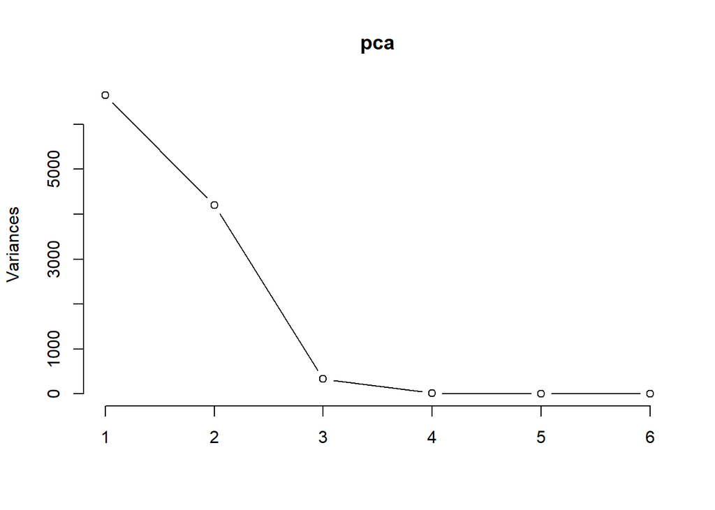

```r
screeplot(pca, type="l")
```

The goal is to find the elbow point, which is around three, so we need three principal compnents, not two.

We can also scale the components:

```r
z_pca <- prcomp(df, scale = T)
z_pca
```

```
## Standard deviations (1, .., p=6):
## [1] 1.4326705 1.3388786 1.2255354 0.6404099 0.4346378 0.2321365
##
## Rotation (n x k) = (6 x 6):
##             PC1         PC2        PC3         PC4         PC5          PC6
## V3  -0.09114827 -0.58425519 -0.4009784  0.42078147  0.54493390 -0.124676477
## V6   0.04839871 -0.60063687  0.2899391 -0.73049746  0.13161004 -0.043364794
## V7  -0.64438451 -0.02361528  0.2734651  0.09658193 -0.16384987 -0.687933805
## V8   0.33229342 -0.48647493  0.3680098  0.46707321 -0.54508091  0.047131875
## V9  -0.18091351 -0.21026321 -0.7129601 -0.23065150 -0.60127428  0.004092771
## V10 -0.65648270 -0.12827733  0.1913773  0.09290235 -0.01533302  0.712098439
```

```r
summary(z_pca)
```

```
## Importance of components:
##                           PC1    PC2    PC3     PC4     PC5     PC6
## Standard deviation     1.4327 1.3389 1.2255 0.64041 0.43464 0.23214
## Proportion of Variance 0.3421 0.2988 0.2503 0.06835 0.03149 0.00898
## Cumulative Proportion  0.3421 0.6409 0.8912 0.95953 0.99102 1.00000
```

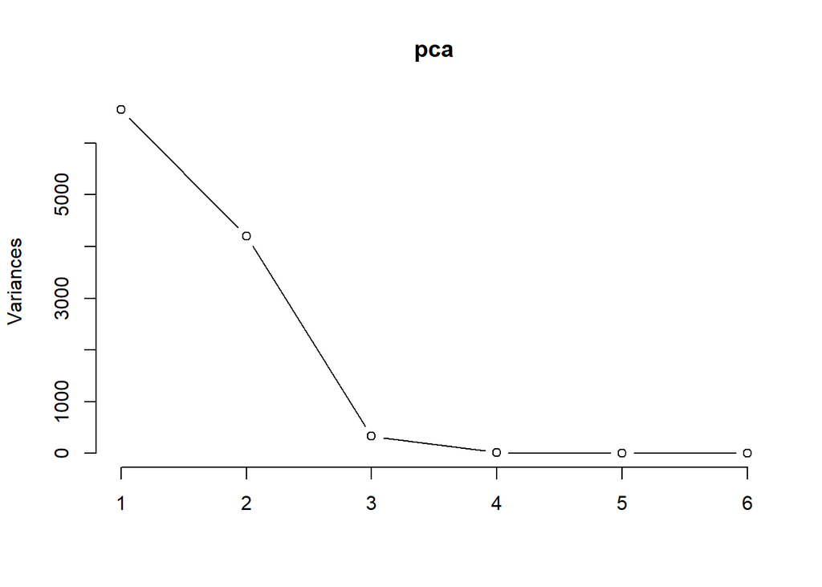

```r
screeplot(pca, type="l")
```

We likewise need three but we will end up accounting for less of the variance with the scaled version.